# MNRiskS2011 Model Monitor Comparison

KMEllickson

May 12, 2016, updated August 1, 2016

### Annual Mean Measurements and MNRiskS Annual Modeled Concentrations were compared using:

-Scatterplots of air toxics, criteria pollutants and single pollutants  
-Model Monitor Statistics

-Measured Data are Collected from the Air Data Folder:  
Folder location for Air Data

### Measured Data are Summarized and assigned an AQS and an MPCA Site ID:

-Arithmetic means were calculated for 2011 by parameter, and site for criteria pollutants  
-MLE means were calculated for air toxics for 2011 by parameter and site  
Prepared and saved here for monitor measurements and the MNRiskS result at the closest receptor

### MNRiskS receptors were assigned to ambient air monitor IDs

-MNRiskS receptors within a 5km buffer of an ambient monitor  
-The closest MNRiskS receptors to each ambient air monitor were also identified. This is the map project used to identify nearest receptors and receptors within 5km of an ambient air monitor  
-There was only one site with a high enough detected level of chromium to provide an annual mean estate. This was from a special monitoring project that was specific to one facility (Grede Foundry). DCI, a stainless steel manufacturer was found to be the source of the high measured chromium. Due to the very specific nature of this monitoring effort, these results were not included in the model-monitor comparison.

### MNRiskS results were pulled and pared down to those closest to monitors and within 5km

-MnRiskS data for all monitored pollutants were pulled from the FTP site, and converted from an *.rsk to an* .rds file using this script.  
This script creates a dataframe from the raw MNRiskS results in the *.rsk format and puts columns names on the dataframe, saves as an* .rds  
-MNRiskS receptors were joined to buffer and closest receptors and saved as a csv file.  
This script pares down MNRiskS results to those at closest receptors and receptors within 5km buffers  
-MNRiskS results are then paired with measured results prior to making plots and calculating model monitor statistics.  
This script pares down MNRiskS results to those at closest receptors and receptors within 5km buffers

-The result of the work in this file was done using two csv files.  
Paired measurements, MNRiskS values, and site IDs.  
Paired measurements, MNRiskS values, receptors, and site IDs.

### Single Pollutant Scatterplots

-The smoothed line is the linear regression line  
-The dotted line is the slope = 1, intercept = 0 abline  
-Click the links to open the pds of these plots  
-Select the back arrow to return to the html  
Prepared and saved here for monitor measurements and the MNRiskS result at the closest receptor

Prepared and saved here for monitor measurements and the mean MNRiskS results for receptors within 5 km (of the monitor)

### Multiple Pollutant Scatterplots (Air Toxics)

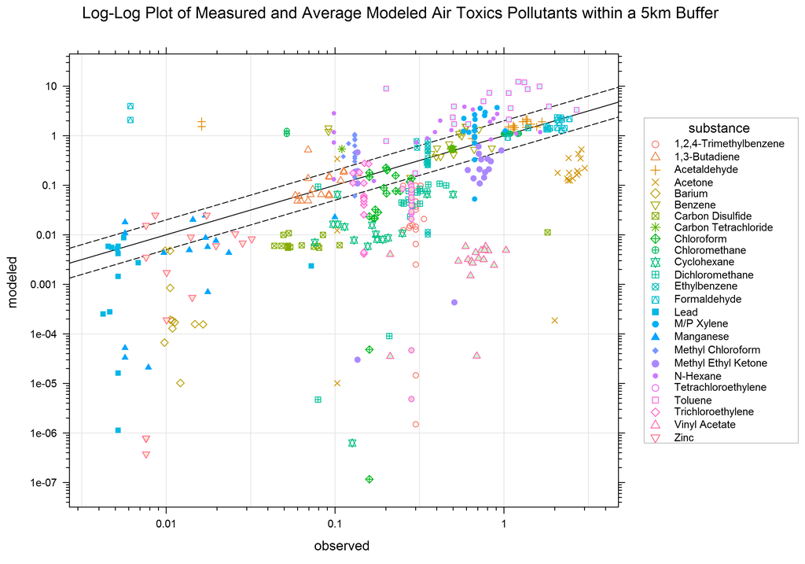

### Multiple Pollutant Scatterplots (Criteria Pollutants)

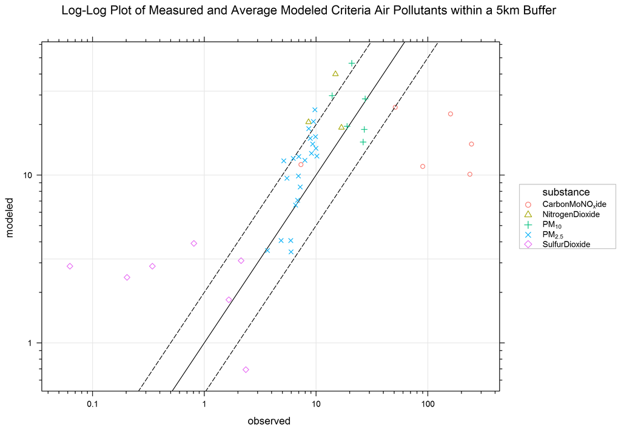

### Pollutant Comparisons (Averaged Receptors Results within 5km buffer of Ambient Monitor)

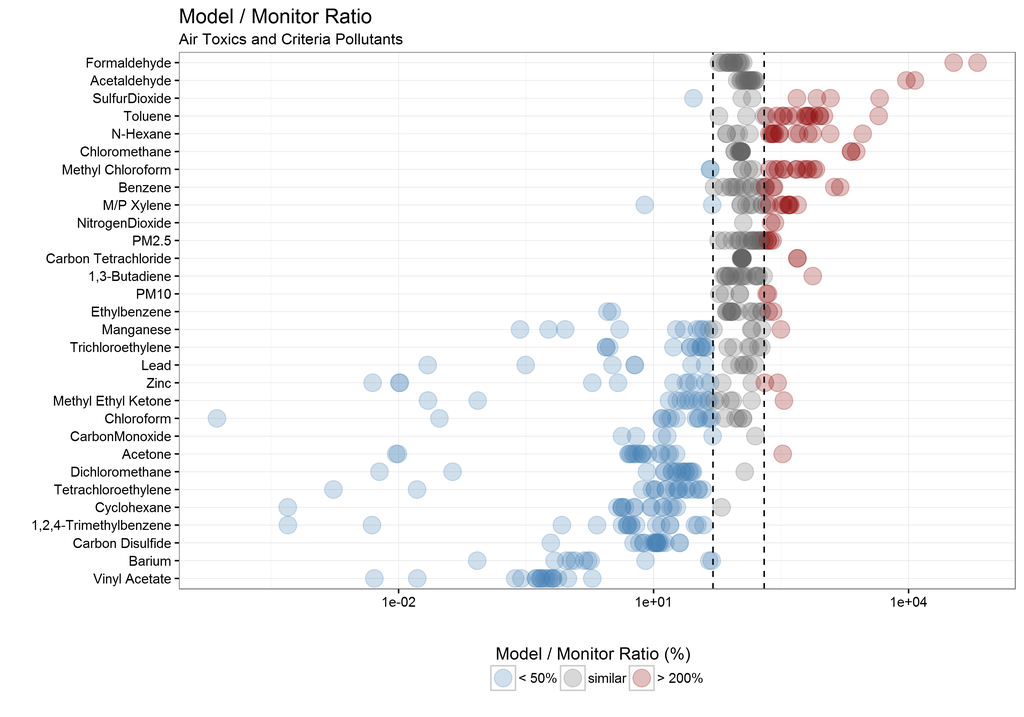

### Pollutant Comparisons (Closest Receptors Results to Ambient Monitor)

[figure not shown]

### Model Monitor Statistical Values

##### The model-monitor statistics were calculated in R using the openair package and the modStats command.

###### modStats(mydata, mod = “mod”, obs = “obs”, statistic = c(“n”, “FAC2”,

###### “MB”, “MGE”, “NMB”, “NMGE”, “RMSE”, “r”, “COE”, “IOA”), type = “default”,

###### rank.name = NULL, …)

All of the specific model monitor comparison statistics are described at this link: (http://www.inside-r.org/packages/cran/openair/docs/modStats) ######The Model-monitor tables are in descending order by the fraction of site-model matches within a factor of 2. Therefore, the pollutants that are at the top of these tables are the best predicted pollutants.

### Model Monitor Statistical Values for Closest Receptors

```
##                 substance Counts   tau   sl FAC2     COE   IOA FrxBias
## 11   Carbon Tetrachloride     37 -0.17 0.16 0.86   -0.09  0.45   20.00
## 18           Acetaldehyde     37  0.42 0.00 0.86   -0.75  0.12   43.18
## 10           Formaldehyde     37  0.26 0.03 0.81   -0.18  0.41   15.94
## 16          Chloromethane     37  0.20 0.09 0.81    0.13  0.56   24.51
## 1                   PM2.5     41  0.59 0.00 0.76   -2.37 -0.41   49.41
## 30        NitrogenDioxide      6  0.33 0.53 0.67   -2.38 -0.41   58.05
## 28                   PM10     15  0.08 0.72 0.60   -7.45 -0.76  105.57
## 3           1,3-Butadiene     37  0.46 0.00 0.59   -3.64 -0.57   58.13
## 2            Ethylbenzene     37 -0.25 0.07 0.54  -28.06 -0.93   24.70
## 14                Benzene     37  0.54 0.00 0.54   -2.53 -0.43   70.30
## 24                   Lead     29  0.07 0.61 0.48   -0.08  0.46  -51.64
## 6                N-Hexane     37  0.42 0.00 0.35   -3.02 -0.50  110.96
## 25              Manganese     33  0.19 0.14 0.33   -0.28  0.36  -59.82
## 29         CarbonMonoxide     12 -0.07 0.83 0.33   -0.40  0.30 -151.97
```

[output cut: 19 more lines]

### Model Monitor Statistical Values for Average MNRiskS Results for Receptors within 5km of a Monitor

```
##                 substance Counts   tau   sl FAC2     COE   IOA FrxBias
## 10          1,3-Butadiene     18  0.50 0.00 0.94   -1.95 -0.32   37.90
## 16           Formaldehyde     18  0.09 0.62 0.89   -0.31  0.35    4.15
## 17   Carbon Tetrachloride     18 -0.18 0.31 0.89   -0.17  0.41   17.93
## 24           Acetaldehyde     18  0.17 0.34 0.89   -0.67  0.16   36.76
## 22          Chloromethane     18  0.44 0.01 0.83    0.14  0.57   21.42
## 9            Ethylbenzene     18 -0.25 0.24 0.78  -17.94 -0.89   10.94
## 7                   PM2.5     22  0.61 0.00 0.77   -1.92 -0.32   44.84
## 5                    PM10      6 -0.20 0.71 0.67   -1.27 -0.12   16.24
## 20                Benzene     18  0.26 0.14 0.67   -2.00 -0.33   54.01
## 23                   Lead     13  0.01 1.00 0.46    0.16  0.58 -103.29
## 15             M/P Xylene     18  0.35 0.07 0.39  -13.32 -0.86   81.24
## 8         NitrogenDioxide      3 -0.33 1.00 0.33   -3.03 -0.50   65.65
## 28      Trichloroethylene     18 -0.05 0.85 0.33  -18.89 -0.90  -50.18
## 4           SulfurDioxide      7 -0.20 0.65 0.29   -1.31 -0.14   80.18
```

[output cut: 16 more lines]